# Introduction to SC19077

## 3.Figure

### LDA for iris data set

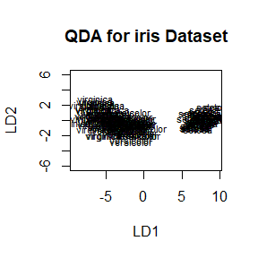

```r
library(MASS)
attach(iris)
train <- sample.int(150,100)
fit <- lda(Species~.,iris[train,])
plot(fit,main="QDA for iris Dataset")
```

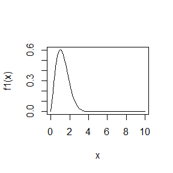

```r
sigma <- 1:4
f1 <- function(x){
x/(sigma[1]^2)*exp(-x^2/(2*sigma[1]^2))}

f2 <- function(x){
x/(sigma[2]^2)*exp(-x^2/(2*sigma[2]^2))}

f3 <- function(x){
x/(sigma[3]^2)*exp(-x^2/(2*sigma[3]^2))}

f4 <- function(x){
x/(sigma[4]^2)*exp(-x^2/(2*sigma[4]^2))}
t <- seq(0,10,0.01)
curve(f1,0,10)
```

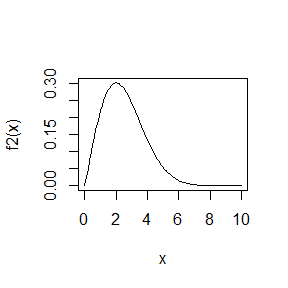

```r
curve(f2,0,10)
```

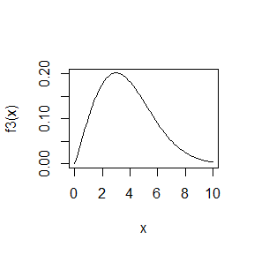

```r
curve(f3,0,10)
```

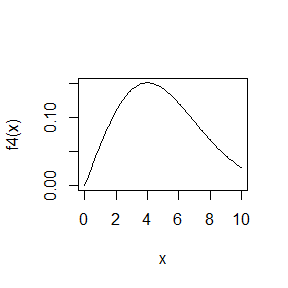

```r
curve(f4,0,10)
```

```r
set.seed(1)
n <- 1e2
rn <- matrix(rep(0,n*4),ncol=4)

i <- c(0,0,0,0)
j <- c(0,0,0,0)

for(k in 1:4){

  while(i[k]<n){
  u <- runif(1)
  j[k] <- j[k]+1
  x <- rgamma(1,shape=2,scale=2*sigma[k]^2)

   if(u <= exp((x-x^2)/(2*sigma[k]^2))){
    i[k] <- i[k]+1
    rn[i[k],k] <- x
   }

  }

}
j
```

```
## [1]  346 1342 2919 6669
```

```r
i
```

```
## [1] 100 100 100 100
```

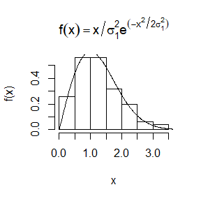

```r
hist(rn[,1],prob=T,xlab='x',ylab='f(x)',main=expression(f(x)==x/sigma[1]^2*e^(-x^2/2*sigma[1]^2)))
lines(t,f1(t))
```

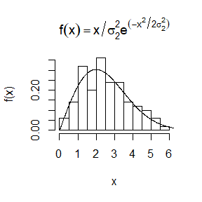

```r
hist(rn[,2],prob=T,xlab='x',ylab='f(x)',main=expression(f(x)==x/sigma[2]^2*e^(-x^2/2*sigma[2]^2)))
lines(t,f2(t))
```

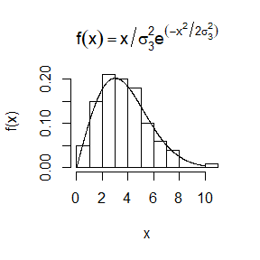

```r
hist(rn[,3],prob=T,xlab='x',ylab='f(x)',main=expression(f(x)==x/sigma[3]^2*e^(-x^2/2*sigma[3]^2)))
lines(t,f3(t))
```

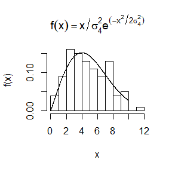

```r
hist(rn[,4],prob=T,xlab='x',ylab='f(x)',main=expression(f(x)==x/sigma[4]^2*e^(-x^2/2*sigma[4]^2)))
lines(t,f4(t))
```

The histograms above show that the mode of the 4 groups of generated samples are all close to the corresponding theoretical mode.

### Question 2

Generate a random sample of size 1000 from a normal location mixture. The components of the mixture have N(0, 1) and N(3, 1) distributions with mixing probabilities p1 and p2 = 1 − p1. Graph the histogram of the sample with density superimposed, for p1 = 0.75. Repeat with different values for p1 and observe whether the empirical distribution of the mixture appears to be bimodal. Make a conjecture about the values of p1 that produce bimodal mixtures.

### Answer

First,generate random sample from the specified normal location mixture with $p_1=0.75$.Then graph the histogram of the sample.

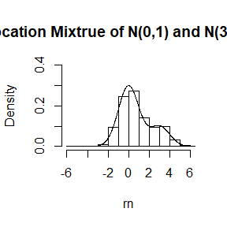

```r
set.seed(2)
n <- 1e3
u <- runif(n)
rn <- ifelse(u<.75,rnorm(n),rnorm(n,3,1))
t <- seq(-6,6,.01)
hist(rn,prob=T,xlim=c(-6,6),ylim=c(0,0.4),main='Normal Location Mixtrue of N(0,1) and N(3,1) for p1=0.75')
lines(t,0.75*dnorm(t,0,1)+0.25*dnorm(t,3,1))
```

Graph the histograms of samples for $19$ different $p_1$ which ranges from $0.05$ to $0.95$.

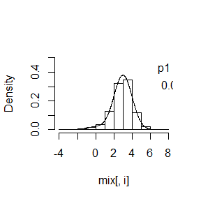

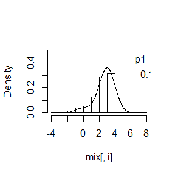

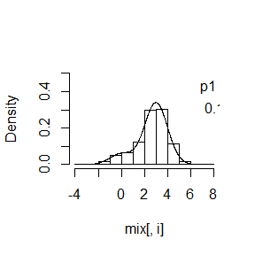

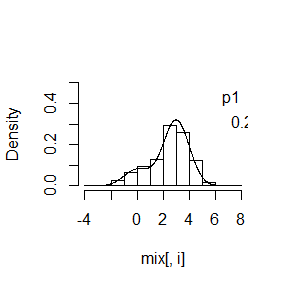

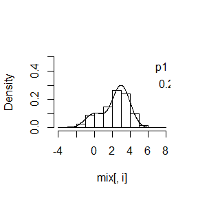

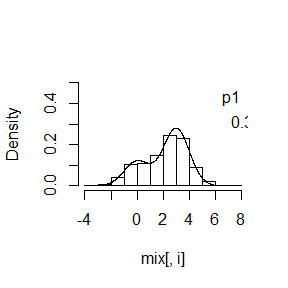

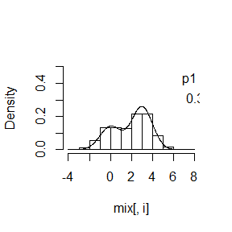

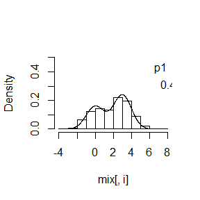

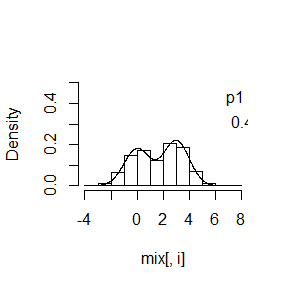

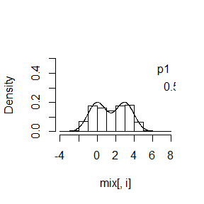

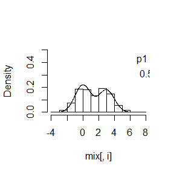

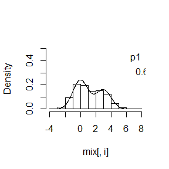

[7 more figures not shown]

```r
p1 <- seq(.05,.95,.05)
mix <- matrix(rep(0,n*19),ncol=19)

for(i in 1:19){
  u <- runif(n)
  mix[,i] <- ifelse(u<p1[i],rnorm(n),rnorm(n,3,1))
}

x <- seq(-4,8,.01)
for(i in 1:19){
  p <- 0.05*i
  hist(mix[,i],prob=T,xlim=c(-4,8),ylim=c(0,0.5),main='')
  legend(5,0.5,title="p1",p,xjust=0,box.lty = 0)
 lines(x,p1[i]*dnorm(x,0,1)+(1-p1[i])*dnorm(x,3,1))
}
```

```r
rmvn <- function(d,n,Sigma){

  T <- matrix(rep(0,d*d),nrow=d)
  for(i in 1:d){
   x <- rchisq(1,n-i+1)
   T[i,i] <- sqrt(x)
  }
  for(i in 2:d){
   for(j in 1:(i-1) ){
      T[i,j] <- rnorm(1)
   }
  }
  A <- T %*% t(T)

  ev <- eigen(Sigma)
  lambda <- ev$values
  v <- ev$vectors

  L <- v %*% diag(sqrt(lambda)) %*% t(v)

  rn <- L %*% A %*% t(L)

}
```

Let’s do simulation.

```r
n <- 5
d <- 3
B <- matrix(c(1,1,1,1,2,4,1,3,9),nrow=3)
Sigma <- (B/10) %*% t(B/10)
Sigma
```

```
##      [,1] [,2] [,3]
## [1,] 0.03 0.06 0.14
## [2,] 0.06 0.14 0.36
## [3,] 0.14 0.36 0.98
```

```r
r <- rmvn(d,n,Sigma)
r
```

```
##           [,1]      [,2]      [,3]
## [1,] 0.1644952 0.3038772 0.6992715
## [2,] 0.3038772 0.5757097 1.3467651
## [3,] 0.6992715 1.3467651 3.2073952
```

The random sample $r$ above is generated from $W_3(\sum ,5)$,where $\sum =$
$$\begin{bmatrix}
0.03&0.06&0.14\\
0.06&0.14&0.36\\
0.14&0.36&0.98
\end{bmatrix}$$

```r
real <- cos(0) - cos(pi/3)
real
```

```
## [1] 0.5
```

```r
set.seed(1)
n <- 1e4
x <- runif(n,0,pi/3)
theta <- round(mean(pi/3*sin(x)),5)
theta <- real
```

```r
set.seed(4)
g <- function(x){pi/3*sin(x)}
f <-function(x){pi/3*x}

n <- 1e4
r <- 1e3
u <- runif(r,0,pi/3)
c <- -cov(f(u),g(u))/var(f(u))
c
```

```
## [1] -0.8451113
```

```r
MC1 <- MC2 <- numeric(n)
for (i in 1:n){
  v <- runif(r,0,pi/3)
  MC1[i] <- mean(g(v))
  MC2[i] <- mean(g(v)+c*(f(v)-pi/3*pi/6))
}
theta1 <- mean(MC1)
theta2 <- mean(MC2)
theta1
```

```
## [1] 0.5001472
```

```r
theta2
```

```
## [1] 0.5000007
```

```r
(var(MC1)-var(MC2))/var(MC1)
```

```
## [1] 0.9937809
```

```r
set.seed(2)

g <- function(x){exp(-x)/(1+x^2)}
n <- 1e3
r <- 1e4

MC1 <- MC2 <- numeric(n)
for (i in 1:n){
  u <- runif(r/2)
  v <- runif(r/2)
  MC1[i] <- round(mean(g(c(u,v))),5)
  MC2[i] <- round(mean(g(c(u,1-u))),5)
}
alpha1 <- round(mean(MC1),5)
alpha2 <- round(mean(MC2),5)
alpha1
```

```
## [1] 0.52475
```

```r
alpha2
```

```
## [1] 0.5248
```

```r
(var(MC1)-var(MC2))/var(MC1)
```

```
## [1] 0.9579657
```

```r
set.seed(3)
k <- 5
Finvers <- function(x){-log(1-(1-exp(-1))*x)}
a <- c(rep(0,5),1)
for (i in 2:5){
  a[i] <- Finvers((i-1)/5)
}
a
```

```
## [1] 0.0000000 0.1351603 0.2914869 0.4768628 0.7046055 1.0000000
```

We get 5 subintervals:$[0,0.135),[0.135,0.291),[0.291,0.477),[0.477,0.705),[0.705,1]$.

```r
n <- 100
r <- 100
g <- function(x){exp(-x)/(1+x^2) * (x>0) * (x<1)}
f <- function(x){exp(-x)/(1-exp(-1))}
p <- function(x){k*f(x)}
Ginvers <- function(a,u){-log(exp(-a)-(1-exp(-1))/5*u)}

theta <- numeric(n)
b <- numeric(k)
for (i in 1:n){
  for (j in 1:k){
    u <- runif(r/k,a[j],a[j+1])
    x <- Ginvers(a[j],u)
    b[j] <- mean( g(x)/p(x) * (x>a[j]) * (x<a[j+1]) )
  }
  theta[i] <- sum(b)
}
round(mean(theta),5)
```

```
## [1] 0.5204
```

```r
se <- 0.0970314
(se^2 - var(theta))/se^2
```

```
## [1] 0.9999549
```

```r
set.seed(1)
m <- 1e4
n <- 20
alpha <- .05
UCL <- LCL <- numeric(m)
for (i in 1:m){
  x <-  rchisq(n,2)
  UCL[i]=mean(x)+var(x)/sqrt(n)*qt(alpha/2,df=n-1,lower.tail = F)
  LCL[i]=mean(x)-var(x)/sqrt(n)*qt(alpha/2,df=n-1,lower.tail = F)
}
r <- mean(LCL < 2 & 2 < UCL)
r
```

```
## [1] 0.9448
```

```r
abs(r - (1-alpha)) - abs(0.956 - (1-alpha))
```

```
## [1] -8e-04
```

```r
se <- sqrt(r*(1-r)/m)
se
```

```
## [1] 0.002283702
```

```r
(0.00689 - se)/0.00689
```

```
## [1] 0.6685483
```

```r
set.seed(2)
m <- 100
a <- 1e3
n <- 50
q <- c(.025,.05,.95,.975)
xq <- qnorm(q,0,sqrt(6/n))

sk <- function(x){
  xbar <- mean(x)
  m3 <- mean((x-xbar)^3)
  m2 <- mean((x-xbar)^2)
  return(m3/m2^1.5)
}

b <- numeric(a)
for(j in 1:a){
    x <- rnorm(n)
    b[j] <- sk(x)
  }
M <- quantile(b,q)

for (i in 1:(m-1)){
   for(j in 1:a){
      x <- rnorm(n)
      b[j] <- sk(x)
   }
   r <- quantile(b,q)
   M <- rbind(M,r)
}

xq.est <- apply(M,2,mean)
se.xq.est <- apply(M,2,sd)
t <- dnorm(xq,0,sqrt(6*(n-2)/((n+1)*(n+3))))
se <- sqrt( q*(1-q)/n/t^2 )
knitr::kable(rbind(xq,xq.est), formate = "html",col.names = c(".025",".05","0.95","0.975"))
```

|  | .025 | .05 | 0.95 | 0.975 |
| --- | --- | --- | --- | --- |
| xq | -0.6789514 | -0.5697940 | 0.5697940 | 0.6789514 |
| xq.est | -0.6451500 | -0.5318477 | 0.5276102 | 0.6379662 |

```r
knitr::kable(rbind(se,se.xq.est), formate = "html",col.names = c(".025",".05","0.95","0.975"))
```

|  | .025 | .05 | 0.95 | 0.975 |
| --- | --- | --- | --- | --- |
| se | 0.1571541 | 0.1157173 | 0.1157173 | 0.1571541 |
| se.xq.est | 0.0321579 | 0.0236436 | 0.0207224 | 0.0283873 |

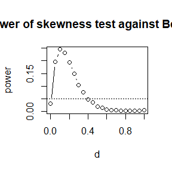

```r
set.seed(1)
alpha <- .05
a <- 1
b <- 10
dis <- seq(0,1,.05)
m <- 1e4
n <- 30
cv <- qnorm(1-alpha/2,0,sqrt(6*(n-2)/(n+1)/(n+3)))
pwr1 <- numeric(length(dis))
sk <- function(x){
  xbar <- mean(x)
  return(mean((x-xbar)^3)/(mean((x-xbar)^2))^1.5)
}

for(i in 1:length(dis)){
  d <- dis[i]
  sktest <- numeric(m)
  for(j in 1:m){
   u <- runif(n)
   x <- ifelse(u<d, rbeta(n,a,a),rbeta(n,b,b))
    sktest[j] <- as.integer(abs(sk(x)) >= cv)
  }
 pwr1[i] <- mean(sktest)
}
plot(dis,pwr1,type="b",xlab="d",ylab="power",main="Power of skewness test against Beta(a,a)")
abline(h=alpha,lty = 3)
```

2. The skewness test of normality with sampling distribution $t(v)$  
   We sample from $H_1$ by choosing a contaminated t distribution $d t(v_1) + (1-d)t(v_2)$ where $v_1\neq v_2$.

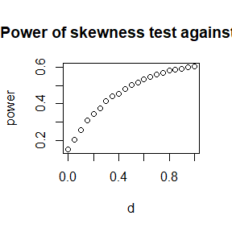

```r
set.seed(2)
alpha <- .05
t1 <- 2
t2 <- 9#parameter of beta distribution
dis <- seq(0,1,.05)#probabilities to sample
m <- 1e4
n <- 30
cv <- qnorm(1-alpha/2,0,sqrt(6*(n-2)/(n+1)/(n+3)))
pwr2 <- numeric(length(dis))
sk <- function(x){
  xbar <- mean(x)
  return(mean((x-xbar)^3)/(mean((x-xbar)^2))^1.5)
}

for(i in 1:length(dis)){
  d <- dis[i]
  sktest <- numeric(m)
  for(j in 1:m){
   u <- runif(n)
   x <- ifelse(u<d, rt(n,t1),rt(n,t2))
   sktest[j] <- as.integer(abs(sk(x)) >= cv)
  }
 pwr2[i] <- mean(sktest)
}
plot(dis,pwr2,type="b",xlab="d",ylab="power",main="Power of skewness test against t(v)")
abline(h=alpha,lty=3)
```

From the figure above we can see the empirical power of skewness test against t distribution is increasing with the increasement of $d$ and are almost all bigger than those of symmetric Beta distribution. This implies that sampling from t-distribution is better than from symmetric Beta in order to calculate the power of skewness test of normality.

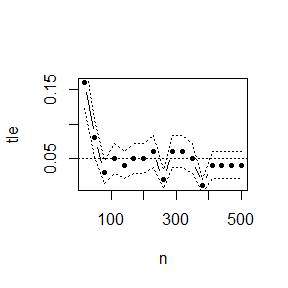

```r
set.seed(3)
alpha <- .05
mu0 <- 1
n <- seq(20,500,30)
m <- 100
p.hat <- numeric(length(n))
for(i in 1:length(n)){
  N <- n[i]
  ttest <- numeric(m)
  for(j in 1:m){
    x <- rchisq(N,1)
    ttest[j] <- t.test(x,mu = mu0)$p.value
  }
  p.hat[i] <- mean(ttest <= alpha)
}
se <- sqrt(p.hat*(1-p.hat)/m)

plot(n,p.hat,ylab="tIe",type="b",pch=20)
abline(h=alpha,lty=3)
lines(n, p.hat+se ,lty=3)
lines(n,p.hat-se, lty=3)
```

2. t-test against $U(0,2)$

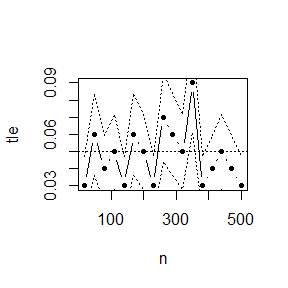

```r
set.seed(4)
alpha <- .05
mu0 <- 1
n <- seq(20,500,30)
m <- 100
p.hat <- numeric(length(n))
for(i in 1:length(n)){
  N <- n[i]
  ttest <- numeric(m)
  for(j in 1:m){
    x <- runif(N,0,2)
    ttest[j] <- t.test(x,mu = mu0)$p.value
  }
  p.hat[i] <- mean(ttest <= alpha)
}
se <- sqrt(p.hat*(1-p.hat)/m)

plot(n,p.hat,ylab="tIe",type="b",pch=20)
abline(h=alpha,lty=3)
lines(n, p.hat+se ,lty=3)
lines(n,p.hat-se, lty=3)
```

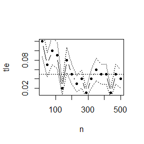

```r
set.seed(6)
alpha <- .05
mu0 <- 1
n <- seq(20,500,30)
m <- 100
p.hat <- numeric(length(n))
for(i in 1:length(n)){
  N <- n[i]
  ttest <- numeric(m)
  for(j in 1:m){
    x <- rexp(N,1)
    ttest[j] <- t.test(x,mu = mu0)$p.value
  }
  p.hat[i] <- mean(ttest <= alpha)
}
se <- sqrt(p.hat*(1-p.hat)/m)

plot(n,p.hat,ylab="tIe",type="b",pch=20)
abline(h=alpha,lty=3)
lines(n, p.hat+se ,lty=3)
lines(n,p.hat-se, lty=3)
```